# MPIDR/INED COVID-19 cases and deaths by age and sex

08 January, 2021

**Purpose**

Population characteristics are key to understand the prevalence, spread and fatality of COVID-19 across countries. The COVID Age Database (COVerAGE-DB) provides a valuable insight into the age-and sex-specific patterns of the COVID-19 cases and deaths.

**Source of data**

COVerAGE-DB is an open-access database including cumulative counts of confirmed COVID-19 cases, deaths, and tests by age and sex. Original data and sources are provided alongside data and measures in standardized and age-harmonized formats. The data were extracted from reports published by official governmental institutions in a variety of formats. The [project page](https://github.com/timriffe/covid_age) and the [medRxiv paper](https://www.medrxiv.org/content/10.1101/2020.09.18.20197228v2) contain the technical details.

The database is still in development. Today it includes 108 countries and 366 subnational areas.

**Limitation**

A limitation of the COVerAGE-DB is the heterogeneous quality of the underlying data, which is difficult to evaluate. Case and death counts are likely underestimated, with underestimation expected to vary by age. As the practices and definitions to count COVID-19 cases and deaths vary by each country, the data should be interpreted with caution when making comparisons across populations or within populations over time.

### Cases and deaths by age

Figure 1. The 97 countries with national data on counts of COVID-19 cases.

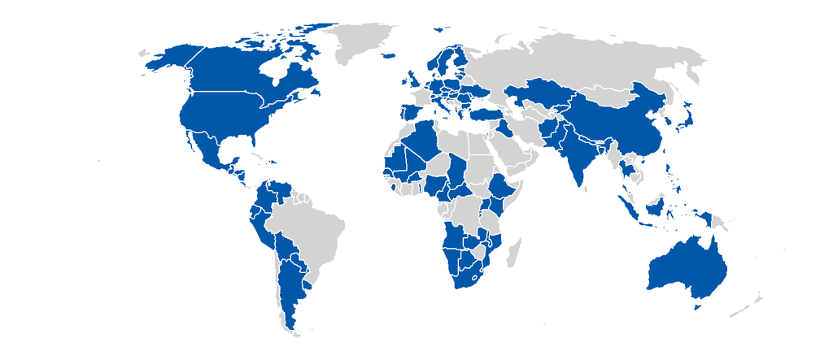

Figure 2. The 79 countries with national data on counts of COVID-19 deaths.

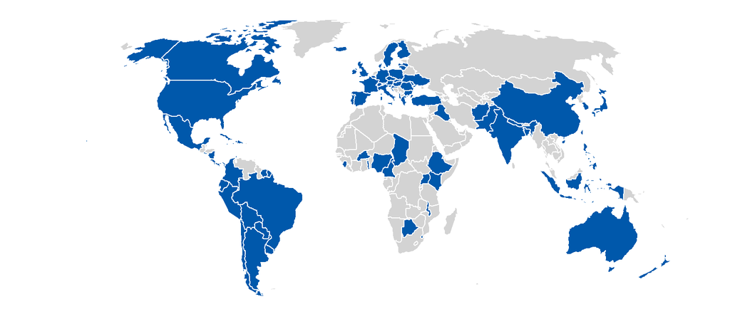

Table 1. The total cases and deaths reported by Johns Hopkins University (JHU) and COVerAGE-DB and COVerAGE-DB’s relative share compared to the JHU numbers. The harmonized data for the age groups 0-4, 5-9, 10-14, 15-19 are shown in the table. Their counts sum to age group 0-19 and we also show the share of the age group 0-19 in all age groups.

| Measure | JHU | COVerAGE-DB | MPIDR/JHU(%) | Age 0-4 | Age 5-9 | Age 10-14 | Age 15-19 | Age 0-19 |
| --- | --- | --- | --- | --- | --- | --- | --- | --- |
| Cases | 88,042,762 | 31,487,305 | 36% | 493,496 | 610,127 | 902,424 | 1,518,920 | 3,524,967 (11%) |
| Deaths | 1,898,530 | 1,132,488 | 60% | 1,030 | 530 | 895 | 1,537 | 3,992 (0.4%) |

Figure 3. The age pyramid by 5-year age interval for COVID-19 total cases, deaths and crude fatality rate (CFR), which is the number of death divided by case for each age group. In order to calculate the CFR, only countries with both cases and deaths data are used.

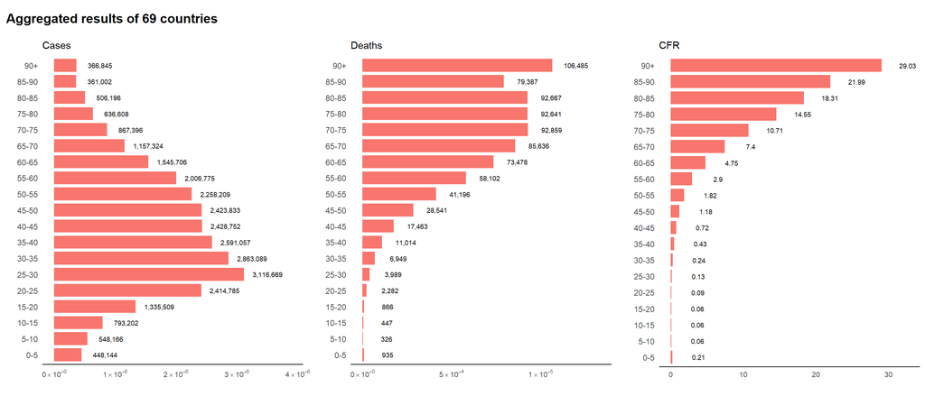

### MPIDR confirmed cases and deaths by age and sex

Figure 4. The 73 countries with national data on sex-specific counts of COVID-19 cases.

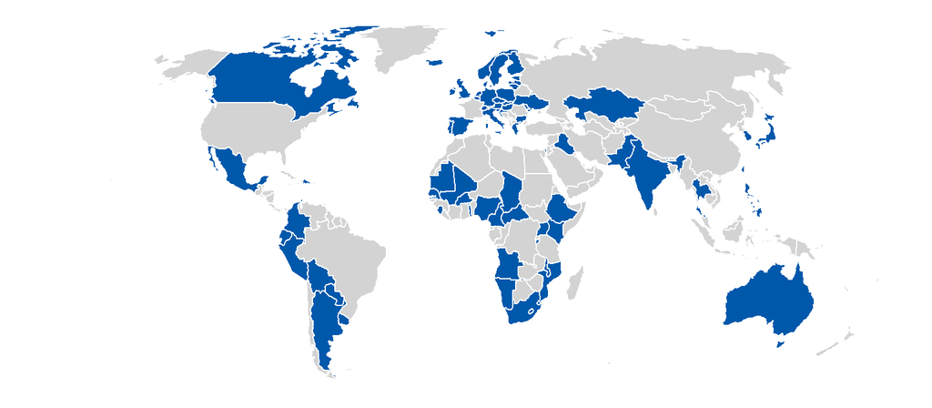

Figure 5. The 64 countries with national data on sex-specific counts of COVID-19 deaths.

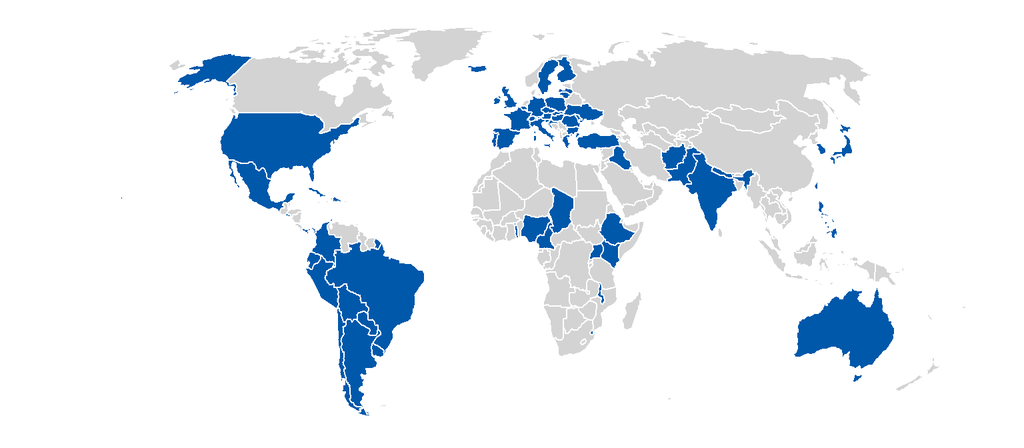

Table 2. The sex-specific cases and deaths reported by Johns Hopkins University (JHU) and COVerAGE-DB. The harmonized data for the age groups 0-4, 5-9, 10-14, 15-19 and 0-19 are shown in the table.

| Measure | Sex | JHU | COVerAGE-DB | Age 0-4 | Age 5-9 | Age 10-14 | Age 15-19 | Age 0-19 |
| --- | --- | --- | --- | --- | --- | --- | --- | --- |
| Cases | Female |  | 9,782,905 | 143,267 | 186,065 | 276,154 | 444,877 | 1,050,363 (11%) |
| Cases | Male |  | 10,238,802 | 158,152 | 201,976 | 298,472 | 475,979 | 1,134,579 (11%) |
| Deaths | Female |  | 454,461 | 420 | 205 | 372 | 660 | 1,657 (0.4%) |
| Deaths | Male |  | 630,786 | 491 | 234 | 430 | 724 | 1,879 (0.3%) |

Figure 4. The sex-specific age pyramid by 5-year age interval for COVID-19 total cases, deaths and crude fatality rate (CFR)

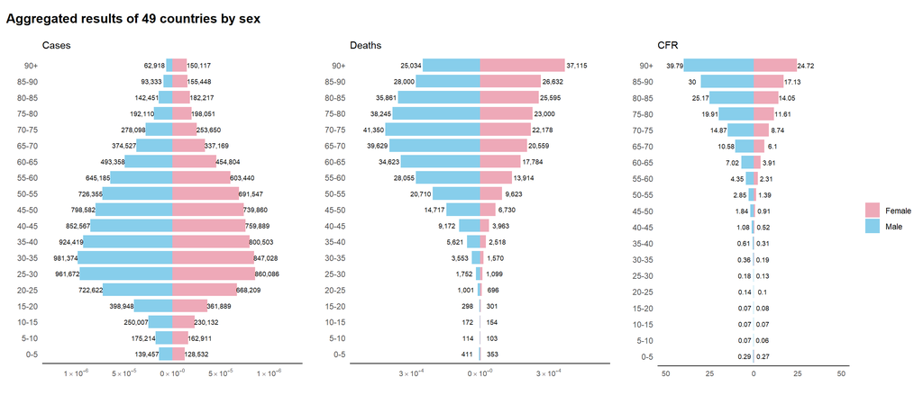

## Reference

Riffe, T., Acosta, E., and The COVerAGE-DB team (2020). COVerAGE-DB: A database of COVID-19 cases and deaths by age. medRxiv https://doi.org/10.1101/2020.09.18.20197228

Dong E, Du H, Gardner L. An interactive web-based dashboard to track COVID-19 in real time. Lancet Inf Dis. 20(5):533-534. https://doi.org/10.1016/S1473-3099(20)30120-1